# Lab 4 - Matan Segal

### Load, Split, and Balance

```python
import pandas as pd
import numpy as np

df = pd.read_csv('acs2017_census_tract_data.csv', encoding='unicode_escape', low_memory=False) # read in the csv file

df.head()
```

|  | TractId | State | County | TotalPop | Men | Women | Hispanic | White | Black | Native | ... | Walk | OtherTransp | WorkAtHome | MeanCommute | Employed | PrivateWork | PublicWork | SelfEmployed | FamilyWork | Unemployment |
| --- | --- | --- | --- | --- | --- | --- | --- | --- | --- | --- | --- | --- | --- | --- | --- | --- | --- | --- | --- | --- | --- |
| 0 | 1001020100 | Alabama | Autauga County | 1845 | 899 | 946 | 2.4 | 86.3 | 5.2 | 0.0 | ... | 0.5 | 0.0 | 2.1 | 24.5 | 881 | 74.2 | 21.2 | 4.5 | 0.0 | 4.6 |
| 1 | 1001020200 | Alabama | Autauga County | 2172 | 1167 | 1005 | 1.1 | 41.6 | 54.5 | 0.0 | ... | 0.0 | 0.5 | 0.0 | 22.2 | 852 | 75.9 | 15.0 | 9.0 | 0.0 | 3.4 |
| 2 | 1001020300 | Alabama | Autauga County | 3385 | 1533 | 1852 | 8.0 | 61.4 | 26.5 | 0.6 | ... | 1.0 | 0.8 | 1.5 | 23.1 | 1482 | 73.3 | 21.1 | 4.8 | 0.7 | 4.7 |
| 3 | 1001020400 | Alabama | Autauga County | 4267 | 2001 | 2266 | 9.6 | 80.3 | 7.1 | 0.5 | ... | 1.5 | 2.9 | 2.1 | 25.9 | 1849 | 75.8 | 19.7 | 4.5 | 0.0 | 6.1 |
| 4 | 1001020500 | Alabama | Autauga County | 9965 | 5054 | 4911 | 0.9 | 77.5 | 16.4 | 0.0 | ... | 0.8 | 0.3 | 0.7 | 21.0 | 4787 | 71.4 | 24.1 | 4.5 | 0.0 | 2.3 |

5 rows × 37 columns

```python
df.info()
```

```
<class 'pandas.core.frame.DataFrame'>
RangeIndex: 74001 entries, 0 to 74000
Data columns (total 37 columns):
TractId             74001 non-null int64
State               74001 non-null object
County              74001 non-null object
TotalPop            74001 non-null int64
Men                 74001 non-null int64
Women               74001 non-null int64
Hispanic            73305 non-null float64
White               73305 non-null float64
Black               73305 non-null float64
Native              73305 non-null float64
Asian               73305 non-null float64
Pacific             73305 non-null float64
VotingAgeCitizen    74001 non-null int64
Income              72885 non-null float64
IncomeErr           72885 non-null float64
IncomePerCap        73256 non-null float64
IncomePerCapErr     73256 non-null float64
Poverty             73159 non-null float64
ChildPoverty        72891 non-null float64
Professional        73190 non-null float64
Service             73190 non-null float64
Office              73190 non-null float64
Construction        73190 non-null float64
Production          73190 non-null float64
Drive               73200 non-null float64
Carpool             73200 non-null float64
Transit             73200 non-null float64
Walk                73200 non-null float64
OtherTransp         73200 non-null float64
WorkAtHome          73200 non-null float64
MeanCommute         73055 non-null float64
Employed            74001 non-null int64
PrivateWork         73190 non-null float64
PublicWork          73190 non-null float64
SelfEmployed        73190 non-null float64
FamilyWork          73190 non-null float64
Unemployment        73191 non-null float64
dtypes: float64(29), int64(6), object(2)
memory usage: 20.9+ MB
```

```python
# removing all missing data

df.replace('', np.nan, inplace=True)
df.dropna(inplace=True)
```

```python
# convert the object columns into categorical int type

from sklearn.preprocessing import LabelEncoder

#drop the county section because it does not give us any contribution data
df = df.drop('County', axis=1)

# quantify the state column
lb_make = LabelEncoder()
df["state_code"] = lb_make.fit_transform(df["State"])

print('Unique State values:',len(np.unique(df['State'])),", code:", len(np.unique(df['state_code'])))

# remove the colums of type object
df1 = df.select_dtypes(exclude='object')
```

```
Unique State values: 52 , code: 52
```

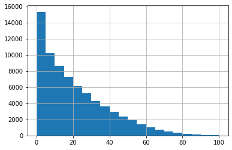

```python
# X should drop Child povetry as well as TractId since it is arbitrary number
X = df1.drop(['ChildPoverty','TractId'], axis=1)

hist = df['ChildPoverty'].hist(bins=20)
```

```python
#set Y into 4 categories
Y = []

med = np.median(df['ChildPoverty'])
per25 = np.percentile(df['ChildPoverty'], 25)
per75 = np.percentile(df['ChildPoverty'], 75)

for x in df['ChildPoverty']:
    if x < per25:
        Y.append(0)
    elif x < med:
        Y.append(1)
    elif x < per75:
        Y.append(2)
    else:
        Y.append(3)

Y = np.array(Y)
print("Number of classes in Y:",len(np.unique(Y)))
unique_elements, counts_elements = np.unique(Y, return_counts=True)
povList = [per25, med, per75]
for i in range(3):
    print(unique_elements[i],' - child poverty percentage less than', povList[i], ':', counts_elements[i])
print(unique_elements[3],' - child povetry percentage is',povList[2],'or more:',counts_elements[3])
```

```
Number of classes in Y: 4
0  - child poverty percentage less than 6.2 : 18019
1  - child poverty percentage less than 16.3 : 18220
2  - child poverty percentage less than 31.6 : 18214
3  - child povetry percentage is 31.6 or more: 18265
```

I chose to classify the child povetry percentage by dividing it into four equally groups. They are not exactly equal since there are many values which equal to the 25th and the 75th percentile as well as the median. I chose this way because we were not given any idea of what treshold we are looking for and I did not want to set one by myself. Since we have not expectation values for what is low or high rate, I wanted to split it as equally as possible, which naturally will set our low and high rate values.

```python
from sklearn.model_selection import train_test_split

# spliting to train and test
X_train, X_test, Y_train, Y_test = train_test_split(X, Y, test_size=0.20, random_state=42, stratify=Y)
print('X_train shape:',X_train.shape)
print('X_test shape:',X_test.shape)
print('Y_train shape:',Y_train.shape)
print('Y_test shape:',Y_test.shape)

print('\nY_train:')
unique_elements, counts_elements = np.unique(Y_train, return_counts=True)
for i in range(4):
    print(unique_elements[i],':',counts_elements[i])

print('\nY_test:')
unique_elements, counts_elements = np.unique(Y_test, return_counts=True)
for i in range(4):
    print(unique_elements[i],':',counts_elements[i])
```

```
X_train shape: (58174, 34)
X_test shape: (14544, 34)
Y_train shape: (58174,)
Y_test shape: (14544,)

Y_train:
0 : 14415
1 : 14576
2 : 14571
3 : 14612

Y_test:
0 : 3604
1 : 3644
2 : 3643
3 : 3653
```

I think we should balance both the training set and the testing set because in this way we will be able to test the performance of our model in the best way. Balancing just the training set and not the testing one may cause of not enough testing for one of the class compare to other, which can cause test result that are not accurate to the reall performance of the model. Since our classes in the target are about the same size, we should test the performance of our model predicting each class equally.

### Pre-processing

##### Not normalized, no one hot encoded

```python
from scipy.special import expit
from sklearn.metrics import accuracy_score
import sys

class TwoLayerPerceptronBase(object):
    def __init__(self, n_hidden=30,
                 C=0.0, epochs=500, eta=0.001, random_state=None):
        np.random.seed(random_state)
        self.n_hidden = n_hidden
        self.l2_C = C
        self.epochs = epochs
        self.eta = eta

    @staticmethod
    def _encode_labels(y):
        """Encode labels into one-hot representation"""
        onehot = pd.get_dummies(y).values.T

        return onehot

    def _initialize_weights(self):
        """Initialize weights with small random numbers."""
        W1_num_elems = (self.n_features_ + 1)*self.n_hidden
        W1 = np.random.uniform(-1.0, 1.0, size=W1_num_elems)
        W1 = W1.reshape(self.n_hidden, self.n_features_ + 1) # reshape to be W

        W2_num_elems = (self.n_hidden + 1)*self.n_output_
        W2 = np.random.uniform(-1.0, 1.0, size=W2_num_elems)
        W2 = W2.reshape(self.n_output_, self.n_hidden + 1)
        return W1, W2

    @staticmethod
    def _sigmoid(z):
        return expit(z)



    @staticmethod
    def _add_bias_unit(X, how='column'):
        """Add bias unit (column or row of 1s) to array at index 0"""
        if how == 'column':
            ones = np.ones((X.shape[0], 1))
            X_new = np.hstack((ones, X))
        elif how == 'row':
            ones = np.ones((1, X.shape[1]))
            X_new = np.vstack((ones, X))
        return X_new

    @staticmethod
    def _L2_reg(lambda_, W1, W2):
        """Compute L2-regularization cost"""
        # only compute for non-bias terms
        return (lambda_/2.0) * np.sqrt(np.mean(W1[:, 1:] ** 2) + np.mean(W2[:, 1:] ** 2))

    def _cost(self,A3,Y_enc,W1,W2):
        '''Get the objective function value'''
        cost = np.mean((Y_enc-A3)**2)
        L2_term = self._L2_reg(self.l2_C, W1, W2)
        return cost + L2_term


class TwoLayerPerceptron(TwoLayerPerceptronBase):
    def _feedforward(self, X, W1, W2):
        """Compute feedforward step
        -----------
        X : Input layer with original features.
        W1: Weight matrix for input layer -> hidden layer.
        W2: Weight matrix for hidden layer -> output layer.
        ----------
        a1-a3 : activations into layer (or output layer)
        z1-z2 : layer inputs

        """
        A1 = self._add_bias_unit(X.T, how='row')
        Z1 = W1 @ A1
        A2 = self._sigmoid(Z1)
        A2 = self._add_bias_unit(A2, how='row')
        Z2 = W2 @ A2
        A3 = self._sigmoid(Z2)
        return A1, Z1, A2, Z2, A3

    def _get_gradient(self, A1, A2, A3, Z1, Z2, Y_enc, W1, W2):
        """ Compute gradient step using backpropagation.
        """
        # vectorized backpropagation
        V2 = -2*(Y_enc-A3)*A3*(1-A3)
        V1 = A2*(1-A2)*(W2.T @ V2)

        grad2 = V2 @ A2.T
        grad1 = V1[1:,:] @ A1.T


        # regularize weights that are not bias terms
        grad1[:, 1:] += W1[:, 1:] * self.l2_C
        grad2[:, 1:] += W2[:, 1:] * self.l2_C


        return grad1, grad2

    def predict(self, X):
        """Predict class labels"""
        _, _, _, _, A3 = self._feedforward(X, self.W1, self.W2)
        y_pred = np.argmax(A3, axis=0)
        return y_pred


    def fit(self, X, y, print_progress=False):
        """ Learn weights from training data."""

        X_data, y_data = X.copy(), y.copy()

        Y_enc = self._encode_labels(y)



        # init weights and setup matrices
        self.n_features_ = X_data.shape[1]
        self.n_output_ = Y_enc.shape[0]
        self.W1, self.W2 = self._initialize_weights()

        self.cost_ = []
        for i in range(self.epochs):

            if print_progress>0 and (i+1)%print_progress==0:
                sys.stderr.write('\rEpoch: %d/%d' % (i+1, self.epochs))
                sys.stderr.flush()

            # feedforward all instances
            A1, Z1, A2, Z2, A3 = self._feedforward(X_data,self.W1,self.W2)


            cost = self._cost(A3,Y_enc,self.W1,self.W2)
            self.cost_.append(cost)

            # compute gradient via backpropagation
            grad1, grad2 = self._get_gradient(A1=A1, A2=A2, A3=A3, Z1=Z1, Z2=Z2, Y_enc=Y_enc,
                                              W1=self.W1, W2=self.W2)

            self.W1 -= self.eta * grad1
            self.W2 -= self.eta * grad2


        return self
```

```python
%%time
params = dict(n_hidden=50,
              C = 0.01,
              epochs=100, # iterations
              eta=0.00001,  # learning rate
              random_state=1)

nn = TwoLayerPerceptron(**params)
nn.fit(X_train, Y_train, print_progress=1)
yhat_1 = nn.predict(X_test)

print('Test acc:',accuracy_score(Y_test,yhat_1))
```

```
Epoch: 100/100
```

```
Test acc: 0.2513751375137514
Wall time: 32.1 s
```

```python
# Function to print the result: how many from each optiona nd the cost graph
import matplotlib.pyplot as plt

def print_result(yhat,cost):
    unique_elements, counts_elements = np.unique(yhat, return_counts=True)

    for idx,i in enumerate(unique_elements):

        print(i,':',counts_elements[idx])

    cost_avgs = [np.mean(x) for x in cost]

    plt.plot(range(len(cost_avgs)), cost_avgs)
    plt.ylabel('Cost')
    plt.xlabel('Epochs')
    plt.tight_layout()
    plt.show()
```

```
0 : 133
1 : 290
2 : 14018
3 : 103
```

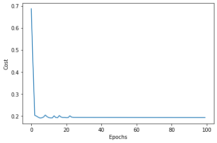

```python
print_result(yhat_1,nn.cost_)
```

##### Normalize with no one hot encoding:

```python
# Normalizing [-1,1]
X_train_norm = -1 + ((X_train-X_train.min())*2/(X_train.max()-X_train.min()))
X_test_norm = -1 + ((X_test-X_test.min())*2/(X_test.max()-X_test.min()))
```

```python
%%time
params = dict(n_hidden=80,
              epochs=100, # iterations
              eta=0.00001,  # learning rate
              random_state=1)

nn1 = TwoLayerPerceptron(**params)
nn1.fit(X_train_norm, Y_train, print_progress=1)
yhat_2 = nn1.predict(X_test_norm)

print('Test acc:',accuracy_score(Y_test,yhat_2))
```

```
Epoch: 100/100
```

```
Test acc: 0.5357535753575358
Wall time: 29.4 s
```

```
0 : 5120
1 : 2160
2 : 2573
3 : 4691
```

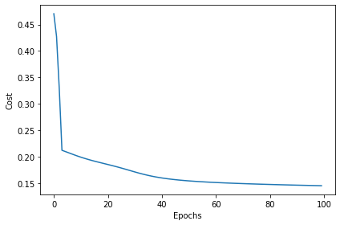

```python
print_result(yhat_2,nn1.cost_)
```

##### Normalized and one hot encoded:

```python
#change  the state_code column into a 1 hot encoding columns in both train and test data

train_state_ones = pd.get_dummies(X_train_norm["state_code"]).values
X_train_onehot = X_train_norm.drop(["state_code"], axis=1)
X_train_onehot = np.hstack((train_state_ones, X_train_onehot))

test_state_ones = pd.get_dummies(X_test_norm["state_code"]).values
X_test_onehot = X_test_norm.drop(["state_code"], axis=1)
X_test_onehot = np.hstack((test_state_ones, X_test_onehot))
```

```python
%%time
params = dict(n_hidden=80,
              epochs=100, # iterations
              eta=0.00001,  # learning rate
              random_state=1)

nn2 = TwoLayerPerceptron(**params)
nn2.fit(X_train_onehot, Y_train, print_progress=1)
yhat_3 = nn2.predict(X_test_onehot)

print('Test acc:',accuracy_score(Y_test,yhat_3))
```

```
Epoch: 100/100
```

```
Test acc: 0.5006188118811881
Wall time: 31.3 s
```

```
0 : 4088
1 : 2570
2 : 3829
3 : 4057
```

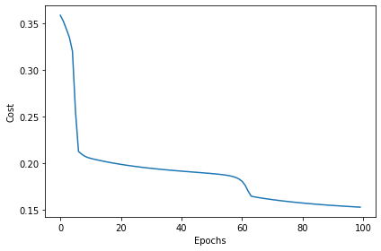

```python
print_result(yhat_3,nn2.cost_)
```

### Comparison between the three models:

I will use the The McNemar’s test statistic. My null hypothesys will be that model x and model y are the same. In order to reject it with a confidence of 90%, I will need a chi square value higher than 2.706.

```python
# return a bool if we 90% confident to reject the null hypothesis
def get_chi_square(b,c):
    chi_square = (abs(b-c)-1)**2/(b+c)
    return chi_square > 2.706

yhat1_acc = yhat_1 == Y_test
yhat2_acc = yhat_2 == Y_test
yhat3_acc = yhat_3 == Y_test


acc_list = [yhat1_acc,yhat2_acc,yhat3_acc]
pairs_to_compare = [[0,1],[1,2],[0,2]]

for x,y in pairs_to_compare:
    b = 0 # x correct, y not
    c = 0 # y correct, x not

    for i in range(len(Y_test)):
        if acc_list[x][i] and not acc_list[y][i]:
            b += 1
        elif not acc_list[x][i] and acc_list[y][i]:
            c += 1

    if get_chi_square(b,c):
        print('model',x, 'is different than model',y,'with 90% confidence')
    else:
        print('we can not assume that model',x,'is different than model',y)
```

```
model 0 is different than model 1 with 90% confidence
model 1 is different than model 2 with 90% confidence
model 0 is different than model 2 with 90% confidence
```

We see that all the model are different than each other, means that according to our accuracy results, the second model, where we normalized the data but did not one hot encode the states, is the best model amoung the three.

### Modeling

I wrote a model which is flexible with the number of layers of neurons we can use

```python
class MultiLayerPerceptronBase(object):
    def __init__(self, n_hidden=30,
                 C=0.0, epochs=50, eta=0.00001, random_state=None, layers = 3):
        np.random.seed(random_state)
        self.n_hidden = n_hidden
        self.l2_C = C
        self.epochs = epochs
        self.eta = eta
        self.layers = layers

    @staticmethod
    def _encode_labels(y):
        """Encode labels into one-hot representation"""
        onehot = pd.get_dummies(y).values.T
        return onehot

    def _initialize_weights(self):
        """Initialize weights with small random numbers."""

        Ws = []

        rows = self.n_hidden
        cols = self.n_features_ + 1
        for i in range(self.layers - 1):
            num_elems = rows*cols
            W1 = np.random.uniform(-1.0, 1.0, size=num_elems)
            W1 = W1.reshape(rows, cols) # reshape to be W
            Ws.append(W1)
            cols = rows + 1


        W2_num_elems = (self.n_hidden + 1)*self.n_output_
        W2 = np.random.uniform(-1.0, 1.0, size=W2_num_elems)
        W2 = W2.reshape(self.n_output_, self.n_hidden + 1)
        Ws.append(W2)

        return Ws

    @staticmethod
    def _sigmoid(z):
        return expit(z)

    @staticmethod
    def _add_bias_unit(X, how='column'):
        """Add bias unit (column or row of 1s) to array at index 0"""
        if how == 'column':
            ones = np.ones((X.shape[0], 1))
            X_new = np.hstack((ones, X))
        elif how == 'row':
            ones = np.ones((1, X.shape[1]))
            X_new = np.vstack((ones, X))
        return X_new

    @staticmethod
    def _L2_reg(lambda_, Ws):
        """Compute L2-regularization cost"""
        # only compute for non-bias terms
        total = 0
        for w in Ws:
            total += np.mean(w[:, 1:] ** 2)

        return (lambda_/2.0) * np.sqrt(total)

    def _cost(self,A3,Y_enc,Ws):
        '''Get the objective function value'''
        cost = np.mean((Y_enc-A3)**2)
        L2_term = self._L2_reg(self.l2_C, Ws)
        return cost + L2_term


class MultiLayerPerceptron(MultiLayerPerceptronBase):
    def _feedforward(self, X, Ws):

        As = []
        Zs = []
        A = self._add_bias_unit(X.T, how='row')
        As.append(A)

        for i,w in enumerate(Ws):
            Z1 = w @ A
            Zs.append(Z1)
            A = self._sigmoid(Z1)
            if i != len(Ws) - 1: # not adding biasing for the last A
                A = self._add_bias_unit(A, how='row')
            As.append(A)

        return As, Zs


    def _get_gradient(self, As, Zs, Y_enc, Ws):
        grads = []
        Vs = []

        # vectorized backpropagation
        V2 = -2*(Y_enc-As[-1])*As[-1]*(1-As[-1])
        Vs.append(V2)

        for i in range(len(As)-2,0,-1):
            if i != self.layers-1:
                # need to take off the bias
                V1 = (As[i]*(1-As[i]))*(Ws[i].T @ Vs[0][1:,:])
            else:
                V1 = As[i]*(1-As[i])*(Ws[i].T @ Vs[0])
            Vs.insert(0,V1)

        lastV = len(Vs)-1
        for i,v in enumerate(Vs):
            if i != lastV:
                g = v[1:,:] @ As[i].T
                grads.append(g)

        grads.append(Vs[lastV] @ As[lastV].T)


        for i,w in enumerate(Ws):
            grads[i][:, 1:] += w[:, 1:] * self.l2_C

        return grads

    def predict(self, X):
        """Predict class labels"""
        As, _ = self._feedforward(X, self.Ws)
        y_pred = np.argmax(As[-1], axis=0)
        return y_pred


    def fit(self, X, y, print_progress=False):
        """ Learn weights from training data."""

        X_data, y_data = X.copy(), y.copy()

        Y_enc = self._encode_labels(y)

        # init weights and setup matrices
        self.n_features_ = X_data.shape[1]
        self.n_output_ = Y_enc.shape[0]
        self.Ws = self._initialize_weights()

        self.cost_ = []
        for i in range(self.epochs):

            if print_progress>0 and (i+1)%print_progress==0:
                sys.stderr.write('\rEpoch: %d/%d' % (i+1, self.epochs))
                sys.stderr.flush()

            # feedforward all instances
            As, Zs = self._feedforward(X_data,self.Ws)


            cost = self._cost(As[-1],Y_enc,self.Ws)
            self.cost_.append(cost)

            # compute gradient via backpropagation
            grads = self._get_gradient(As=As, Zs=Zs, Y_enc=Y_enc, Ws=self.Ws)

            for j,w in enumerate(self.Ws):
                self.Ws[j] -= self.eta * grads[j]


        return self
```

```
Epoch: 70/70
```

```
Test acc: 0.47483498349834985
0 : 5636
1 : 2794
2 : 1321
3 : 4793
```

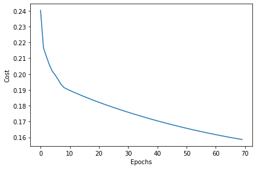

```python
# Three layers

params = dict(n_hidden=70,
              epochs=70,
              eta=0.00001,
              random_state=1,
              layers = 3)

MLP3 = MultiLayerPerceptron(**params)
MLP3.fit(X_train_onehot, Y_train, print_progress=1)
yhat = MLP3.predict(X_test_onehot)

print('Test acc:',accuracy_score(Y_test,yhat))
print_result(yhat,MLP3.cost_)
```

```
Epoch: 100/100
```

```
Test acc: 0.47634763476347636
0 : 6997
1 : 1303
2 : 1289
3 : 4955
```

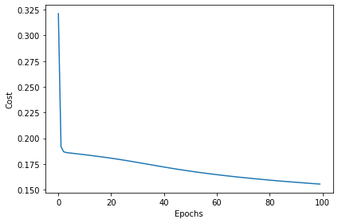

```python
# 4 Layers

params = dict(n_hidden=50,
              epochs=100,
              eta=0.00001,
              random_state=1,
              layers = 4)


MLP4 = MultiLayerPerceptron(**params)
MLP4.fit(X_train_onehot, Y_train, print_progress=1)
yhat = MLP4.predict(X_test_onehot)

print('Test acc:',accuracy_score(Y_test,yhat))
print_result(yhat,MLP4.cost_)
```

```
Epoch: 100/100
```

```
Test acc: 0.49257425742574257
0 : 3026
1 : 1759
2 : 2787
3 : 6972
```

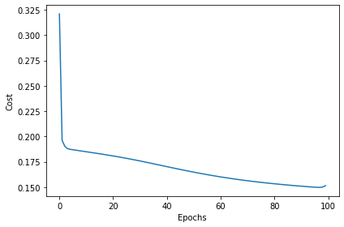

```python
# 5 Layers

params = dict(n_hidden=50,
              epochs=100,
              eta=0.00001,
              random_state=1,
              layers = 5)

MLP5 = MultiLayerPerceptron(**params)
MLP5.fit(X_train_onehot, Y_train, print_progress=1)
yhat_5 = MLP5.predict(X_test_onehot)

print('Test acc:',accuracy_score(Y_test,yhat_5))
print_result(yhat_5,MLP5.cost_)
```

### Implementation of an adaptive learning technique

#### Momentum

```python
class MLPmomentum(MultiLayerPerceptron):
    def fit(self, X, y, print_progress=False, alpha = 0.1):

        self.alpha = alpha
        X_data, y_data = X.copy(), y.copy()

        Y_enc = self._encode_labels(y)

        # init weights and setup matrices
        self.n_features_ = X_data.shape[1]
        self.n_output_ = Y_enc.shape[0]
        self.Ws = self._initialize_weights()

        #current delta, so we can use it in the for loop
        curr_delta = []
        # start momentum at zero for previous updates
        delta_prev = []
        for w in self.Ws:
            delta_prev.append(np.zeros(w.shape))
            curr_delta.append(np.zeros(w.shape))

        self.cost_ = []
        for j in range(self.epochs):

            #adaptive learning rate
            self.eta *= 0.99

            if print_progress>0 and (j+1)%print_progress==0:
                sys.stderr.write('\rEpoch: %d/%d' % (j+1, self.epochs))
                sys.stderr.flush()

            # feedforward all instances
            As, Zs = self._feedforward(X_data,self.Ws)

            cost = self._cost(As[-1],Y_enc,self.Ws)
            self.cost_.append(cost)

            # compute gradient via backpropagation
            grads = self._get_gradient(As=As, Zs=Zs, Y_enc=Y_enc, Ws=self.Ws)

            # use momentum
            for i in range(len(delta_prev)):
                curr_delta[i] = self.eta * grads[i]
                self.Ws[i] -= (curr_delta[i] + (self.alpha * delta_prev[i])) # update with momentum

            #update prev delta:
            for i in range(len(delta_prev)):
                curr_delta[i] = delta_prev[i]

        return self
```

```python
params = dict(n_hidden=25,
              epochs=120,
              eta=0.00005,  # larger eta since we using an adaptive technique
              random_state=1,
              layers = 5)

MLP_mom = MLPmomentum(**params)
MLP_mom.fit(X_train_onehot, Y_train, print_progress=1, alpha = 0.01)
yhat_mom = MLP_mom.predict(X_test_onehot)

print('Test acc:',accuracy_score(Y_test,yhat_mom))
```

```
Epoch: 120/120
```

```
Test acc: 0.4991061606160616
```

```
0 : 6888
1 : 1122
2 : 1501
3 : 5033
```

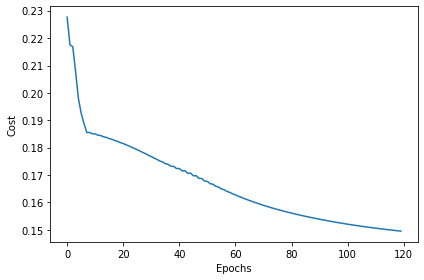

```python
print_result(yhat_mom,MLP_mom.cost_)
```

### Comparison between regular 5 layers perceptron and one with adaptive technique

Like I did before, I will use the McNemar’s test statistic to compare between the two models.

```python
yhat5_acc = yhat_5 == Y_test
yhat_mom_acc = yhat_mom == Y_test

b = 0 # no momentum correct, momentum not
c = 0 # momentum correct, no momentum not

for i in range(len(Y_test)):
    if yhat5_acc[i] and not yhat_mom_acc[i]:
        b += 1
    elif not yhat5_acc[i] and yhat_mom_acc[i]:
        c += 1

if get_chi_square(b,c):
    print('model',x, 'is different than model',y,'with 90% confidence')
else:
    print('we can not assume that model',x,'is different than model',y)
```

```
we can not assume that model 0 is different than model 2
```

### Exceptional Work

#### Implement adaptive momentum (AdaM)

```python
class MLP_AdaM(MultiLayerPerceptron):
    def fit(self, X, y, print_progress=False):

        X_data, y_data = X.copy(), y.copy()

        Y_enc = self._encode_labels(y)

        # init weights and setup matrices
        self.n_features_ = X_data.shape[1]
        self.n_output_ = Y_enc.shape[0]
        self.Ws = self._initialize_weights()

        # initialize all the parameters
        beta1 = 0.9
        beta2 = 0.999
        epsilon = 10**-8
        mt = []
        vt = []
        prev_mt = []
        prev_vt = []
        mt_hat = []
        vt_hat = []

        for w in self.Ws:
            prev_mt.append(np.zeros(w.shape))
            prev_vt.append(np.zeros(w.shape))

        self.cost_ = []
        for j in range(self.epochs):

            if print_progress>0 and (j+1)%print_progress==0:
                sys.stderr.write('\rEpoch: %d/%d' % (j+1, self.epochs))
                sys.stderr.flush()

            # feedforward all instances
            As, Zs = self._feedforward(X_data,self.Ws)

            cost = self._cost(As[-1],Y_enc,self.Ws)
            self.cost_.append(cost)

            # compute gradient via backpropagation
            grads = self._get_gradient(As=As, Zs=Zs, Y_enc=Y_enc, Ws=self.Ws)

            # calculate mt - grad momentum, vt - square grad momentum
            for i in range(len(prev_mt)):
                # for the first time just append, later update
                if j == 0:
                    mt.append(beta1 * prev_mt[i] + (1-beta1) * grads[i])
                    vt.append(beta2 * prev_vt[i] + (1-beta2) * ((grads[i])**2))
                    mt_hat.append(mt[i]/(1-beta1))
                    vt_hat.append(vt[i]/(1-beta2))
                else:
                    mt[i] = beta1 * prev_mt[i] + (1-beta1) * grads[i]
                    vt[i] = beta2 * prev_vt[i] + (1-beta2) * ((grads[i])**2)
                    mt_hat[i] = mt[i]/(1-(beta1**j))
                    vt_hat[i] = vt[i]/(1-(beta2**j))

                self.Ws[i] -= self.eta*mt_hat[i]/(vt_hat[i]**0.5 + epsilon)

            #update prev mt,vt:
            for i in range(len(prev_vt)):
                prev_vt[i] = vt[i]
                prev_mt[i] = mt[i]

        return self
```

```python
params = dict(n_hidden=25,
              epochs=100,
              eta=0.01, # larger eta since we using an adaptive technique
              random_state=1,
              layers = 5)

MLP_Adam = MLP_AdaM(**params)
MLP_Adam.fit(X_train_onehot, Y_train, print_progress=1)
yhat_AdaM = MLP_Adam.predict(X_test_onehot)

print('Test acc:',accuracy_score(Y_test,yhat_AdaM))
```

```
Epoch: 100/100
```

```
Test acc: 0.6569031903190319
```

```
0 : 4003
1 : 3261
2 : 3160
3 : 4120
```

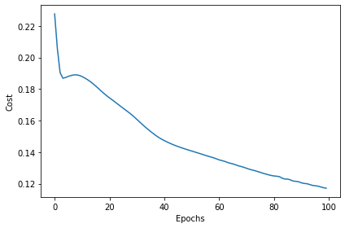

```python
print_result(yhat_AdaM,MLP_Adam.cost_)
```

We can see that the 5 layers preceptron with AdaM implamentation is the best model by far amoung all the model I built in this lab.